# Machine Learning Predictive Algorithm

Andres Mauricio Castro

## Executive Summary

Using devices such as Jawbone Up, Nike FuelBand, and Fitbit it is now possible to collect a large amount of data about personal activity relatively inexpensively. These type of devices are part of the quantified self movement - a group of enthusiasts who take measurements about themselves regularly to improve their health, to find patterns in their behavior, or because they are tech geeks. One thing that people regularly do is quantify how much of a particular activity they do, but they rarely quantify how well they do it.

In this study, we are going to construct a predictive model, in order to predict the manner how the persons did the exercise.

## Data Processing

We load the both data sets for the study, and required packages.

```r
library(caret)
```

```r
path <- getwd()
if(!file.exists(path)){
  dir.create(path)
}

trainingSetUrl <- "https://d396qusza40orc.cloudfront.net/predmachlearn/pml-training.csv"
testSetUrl <- "https://d396qusza40orc.cloudfront.net/predmachlearn/pml-testing.csv"

trainingFileName <- "pml-training.csv"
testFileName <- "pml-testing.csv"

if (!file.exists(trainingFileName)) {
    download.file(trainingSetUrl,file.path(path, trainingFileName))
}
if (!file.exists(testFileName)) {
    download.file(testSetUrl,file.path(path, testFileName))
}

trainingData <- read.csv(file=trainingFileName,head=TRUE,sep=",",na.strings=c('NA','','#DIV/0!'))
testingData <- read.csv(file=testFileName,head=TRUE,sep=",",na.strings=c('NA','','#DIV/0!'))
```

## Data Processing

By looking at the structure of the columns in the training data set, we find a lot of columns with NA values. The first step is to clean the data set, by getting rid of such columns. Also, we attempt to drop the columns which are not numeric, or with continuous values, which are not useful to construct our model.

```r
head(trainingData)
```

[output not shown]

[output cut: 265 more lines]

```r
trainingData <- trainingData[sapply(trainingData, function(x) !any(is.na(x)))]
trainingData <- trainingData[,-c(1,2,3,4,5,6)]
```

## Model Construction

```r
M <- abs(cor(trainingData[,-54]))
diag(M) <- 0
which(M > 0.9,arr.ind=T)
```

```
##                  row col
## total_accel_belt   5   2
## accel_belt_y      10   2
## accel_belt_z      11   2
## accel_belt_x       9   3
## roll_belt          2   5
## accel_belt_y      10   5
## accel_belt_z      11   5
## pitch_belt         3   9
## roll_belt          2  10
## total_accel_belt   5  10
## accel_belt_z      11  10
## roll_belt          2  11
## total_accel_belt   5  11
## accel_belt_y      10  11
## gyros_arm_y       20  19
## gyros_arm_x       19  20
## gyros_dumbbell_z  34  32
## gyros_forearm_z   47  32
## gyros_dumbbell_x  32  34
## gyros_forearm_z   47  34
## gyros_dumbbell_x  32  47
## gyros_dumbbell_z  34  47
```

We plot the variable classe in the resulting training sub set, and see the classifications are within an order of magnitude of one another.

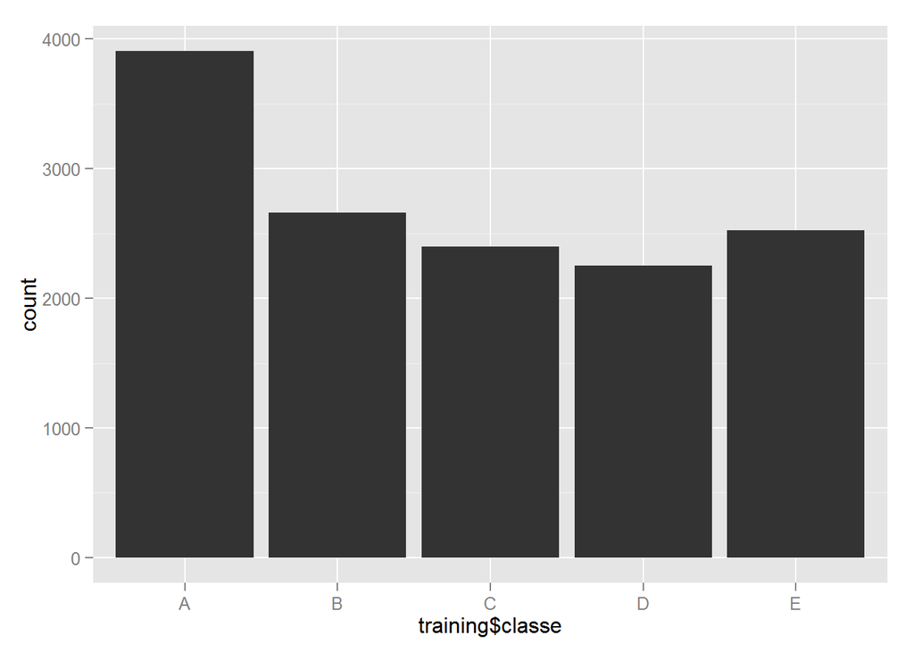

```r
inTrain <- createDataPartition(y=trainingData$classe,p=0.7, list=FALSE)
training <- trainingData[inTrain,]
testing <- trainingData[-inTrain,]

qplot(training$classe)
```

As this is a problem of classification, a random forest model is chosen. For simplicity, we train our model, indicating to the algorithm to perform a pre-processing transformation, by using the principal components analysis, and evaluate the final model.

```r
modelFit <- train(training$classe ~ .,method="rf",preProcess="pca",data=training)
confusionMatrix(testing$classe,predict(modelFit,testing))
```

```
## Confusion Matrix and Statistics
##
##           Reference
## Prediction    A    B    C    D    E
##          A 1657    6    5    4    2
##          B   14 1105   19    0    1
##          C    3   11 1001    9    2
##          D    1    2   51  910    0
##          E    1    0    4    4 1073
##
## Overall Statistics
##
##                Accuracy : 0.9764
##                  95% CI : (0.9722, 0.9801)
##     No Information Rate : 0.2848
##     P-Value [Acc > NIR] : < 2.2e-16
##
##                   Kappa : 0.9701
##  Mcnemar's Test P-Value : 2.145e-06
##
## Statistics by Class:
##
##                      Class: A Class: B Class: C Class: D Class: E
## Sensitivity            0.9887   0.9831   0.9269   0.9817   0.9954
## Specificity            0.9960   0.9929   0.9948   0.9891   0.9981
## Pos Pred Value         0.9898   0.9701   0.9756   0.9440   0.9917
## Neg Pred Value         0.9955   0.9960   0.9837   0.9965   0.9990
## Prevalence             0.2848   0.1910   0.1835   0.1575   0.1832
## Detection Rate         0.2816   0.1878   0.1701   0.1546   0.1823
## Detection Prevalence   0.2845   0.1935   0.1743   0.1638   0.1839
## Balanced Accuracy      0.9923   0.9880   0.9608   0.9854   0.9967
```

Our model is a good one, with 98% of accuracy. Now, we can proceed to perform our predictions; firstly, we clean the testing data set provided, and apply our model, to solve our problem.

These are the predictions, of how the exercise was performed, for the 20 records in the data set.

```r
testingData <- testingData[sapply(testingData, function(x) !any(is.na(x)))]
testingData <- testingData[,-c(1,2,3,4,5,6)]
predictions <- predict(modelFit, testingData)
print(predictions)
```

```
##  [1] B A A A A E D B A A B C B A E E A B B B
## Levels: A B C D E
```